# Linear_regression_on_salary_data

### In this Task we can predict the salary data on the basis their experice what they actually get and we can predict the salary data on the basis of the dataset.

## Firstly, we Load the data on the variable, as we see ww have a dataset in xlsx format so we add library “readxl” is used for excel data.

## we check the dataset

```r
par(mfrow = c(1,2))
head(salary_Data)
```

```
## # A tibble: 6 x 2
##   YearsExperience Salary
##             <dbl>  <dbl>
## 1             1.1  39343
## 2             1.3  46205
## 3             1.5  37731
## 4             2    43525
## 5             2.2  39891
## 6             2.9  56642
```

```r
summary(salary_Data)
```

```
##  YearsExperience      Salary
##  Min.   : 1.100   Min.   : 37731
##  1st Qu.: 3.200   1st Qu.: 56721
##  Median : 4.700   Median : 65237
##  Mean   : 5.313   Mean   : 76003
##  3rd Qu.: 7.700   3rd Qu.:100545
##  Max.   :10.500   Max.   :122391
```

## we start EDA process on the data EDA Stands for “Explorartory Data Analysis” and it is also known as “Pre processing”

# 1. Variable identification

# 2. Univariate analysis

# 3. Bivariate analysis

# 4. Missing Value Treatment

# 5. Outlier Treatment

# 6. varible transformation

# 7. variable creation

# but as we see we do not have any outlier no any missing values and no need to ananlysis (univariate and bivariate) becouase we have a small two column dataset.

# but else we can check outlier with the graph

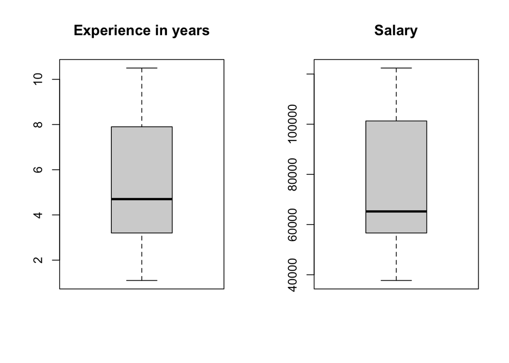

## library “caTools” helps to break the dataset because we need to break the dataset in two dataset test and train.

# training dataset and test dataset

# sample.split works for only target variable and splitratio convert part you want to take for training

```r
library(caTools)

set.seed(10)

split_salary_data <- sample.split(salary_Data$Salary, SplitRatio = 0.75)

split_salary_data
```

```
##  [1]  TRUE  TRUE  TRUE FALSE  TRUE  TRUE  TRUE  TRUE  TRUE  TRUE FALSE  TRUE
## [13]  TRUE  TRUE  TRUE  TRUE  TRUE  TRUE  TRUE FALSE FALSE  TRUE FALSE  TRUE
## [25]  TRUE FALSE FALSE  TRUE FALSE  TRUE
```

## as we see we have a split data in form of True and False so we have to compaew True for training and Fase for Test

```r
train = subset(salary_Data, split_salary_data == T)

testdata = subset(salary_Data, split_salary_data == F)

head(train)
```

```
## # A tibble: 6 x 2
##   YearsExperience Salary
##             <dbl>  <dbl>
## 1             1.1  39343
## 2             1.3  46205
## 3             1.5  37731
## 4             2.2  39891
## 5             2.9  56642
## 6             3    60150
```

```r
head(testdata)
```

```
## # A tibble: 6 x 2
##   YearsExperience Salary
##             <dbl>  <dbl>
## 1             2    43525
## 2             3.9  63218
## 3             6    93940
## 4             6.8  91738
## 5             7.9 101302
## 6             9   105582
```

## creating the model on training Data

```r
model <- lm(formula = Salary~., data = train)

summary(model)
```

```
##
## Call:
## lm(formula = Salary ~ ., data = train)
##
## Residuals:
##    Min     1Q Median     3Q    Max
##  -7549  -5628  -1570   5333  11015
##
## Coefficients:
##                 Estimate Std. Error t value Pr(>|t|)
## (Intercept)        25508       2749   9.279 1.10e-08 ***
## YearsExperience     9426        510  18.483 4.84e-14 ***
## ---
## Signif. codes:  0 '***' 0.001 '**' 0.01 '*' 0.05 '.' 0.1 ' ' 1
##
## Residual standard error: 6197 on 20 degrees of freedom
## Multiple R-squared:  0.9447, Adjusted R-squared:  0.9419
## F-statistic: 341.6 on 1 and 20 DF,  p-value: 4.842e-14
```

## predict the model with the test data

```r
prediction <- predict(model, testdata)

prediction
```

```
##         1         2         3         4         5         6         7         8
##  44358.76  62267.28  82060.91  89601.35  99969.44 110337.53 115050.30 122590.73
```

## So, we can add these data on the test dataframe and we the difference its easy to say model is corrrect or not

# we can use cbind for the combine the columns in the test dataset

```r
difference <- (testdata$Salary - prediction)
testdata <- cbind(testdata, prediction, difference)

testdata
```

```
##   YearsExperience Salary prediction difference
## 1             2.0  43525   44358.76  -833.7559
## 2             3.9  63218   62267.28   950.7190
## 3             6.0  93940   82060.91 11879.0861
## 4             6.8  91738   89601.35  2136.6545
## 5             7.9 101302   99969.44  1332.5611
## 6             9.0 105582  110337.53 -4755.5324
## 7             9.5 116969  115050.30  1918.6979
## 8            10.3 122391  122590.73  -199.7337
```

## we also find mean absolute percentage error or deviation (MAPE or MAPD)

```r
mape <- mean(abs(difference)/ testdata$Salary)
mape
```

```
## [1] 0.03252128
```

## as we see our map is very low 3% . So the prediction is enough to say more experience have more salary.